# An approach for measuring partisan segregation in political media consumption

August 9, 2019

## Open materials

Paper, slides, code, and data available at:

jacob-long.com

## Problem

- Lots of talk about “echo chambers”
  - Surely this is a continuous phenomenon
  - Segregation a clearer concept
- Segregation in this context = different media diets by partisanship
- Related to but distinct from selective exposure theory
  - Interest in *how much* segregation, not *why* there is segregation
- How do you measure this?

## What I am presenting

- Using network analysis to approach this problem
  - Residential (racial) segregation
- Focusing on people as unit of analysis
  - Rather than sources or audiences
- Goal: a number that could be plugged into a regression model

## What I am presenting

A measure that…

- Can describe *people*
  - Person X has Y level of segregation
- Accommodates multi-party systems
- Is comparable across contexts
  - parties, countries, non-media contexts
- Requires no more complex designs than usual

## Past work

Selective exposure research

- Control for partisanship, ideology, congenial media use
- No preference/positive preference for out-party media
- *Not* a measure of the information environment!

## Past work

Tracking data (e.g., Bakshy, Messing, & Adamic, 2015)

- Define sources as liberal/neutral/conservative based on who tends to click/share
- How much liberal media on conservatives’ news feeds, vice versa?
  - About 25%

## Past work

Tracking data

- Gentzkow & Shapiro (2011) have individual-level web and TV tracking data
  - Dichotomize sources
  - True ideology unknown for many respondents
  - Minimal “segregation” (= .08 on a measure bounded at 0 and 1)
  - Similar design and results from Flaxman & Goel (2016)

## Spectral Segregation Index (SSI)

- Requires a network/graph representation

For people:

- Nodes are people, edges reflect co-consumption
- Weight of edges = # of shared sources

For sources:

- Nodes are sources, edges reflect co-consumers
- Weight of edges = # of pairs of people who both use source

## Data

Pew Research Center’s American Trends Panel, Wave 1 (2014)

- N = 3,308
- Represenative of adults in USA
- 66 political media sources
  - Mix of TV, internet, print, radio (some overlapping)
  - Did you get news from in the past week? (Yes/No)
  - About 5 sources per respondent
- Sources coded as left/Democrat-favoring, right/Republican-favoring, or non-partisan
- Respondents self-report partisanship

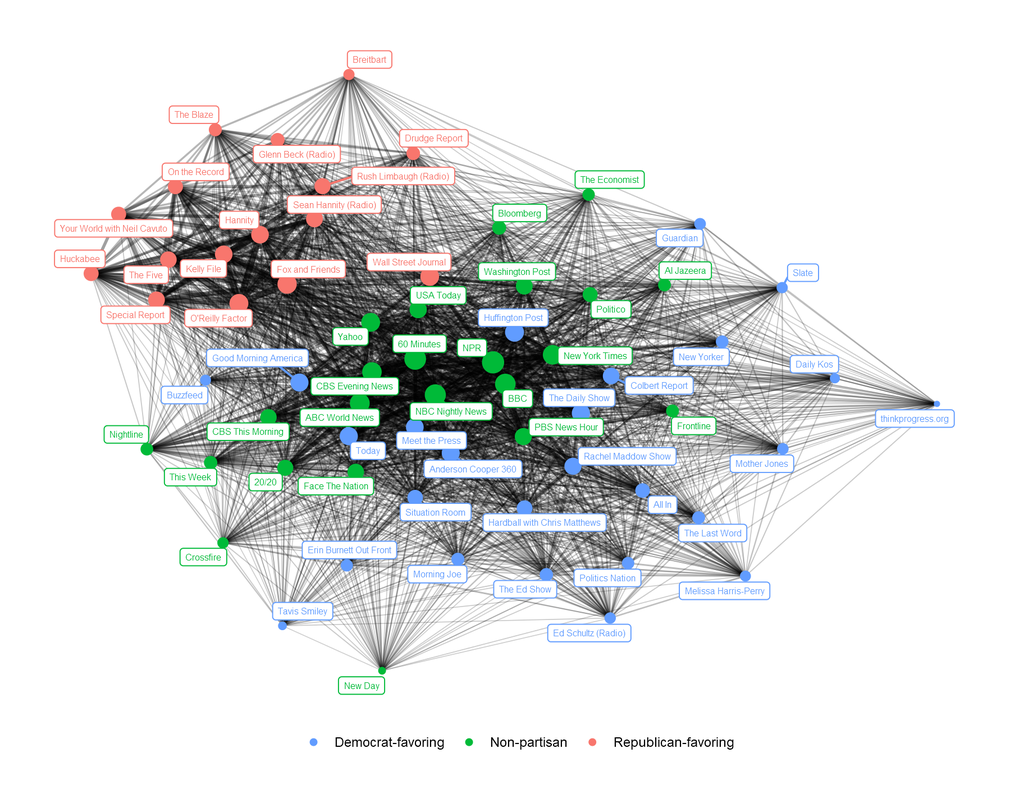

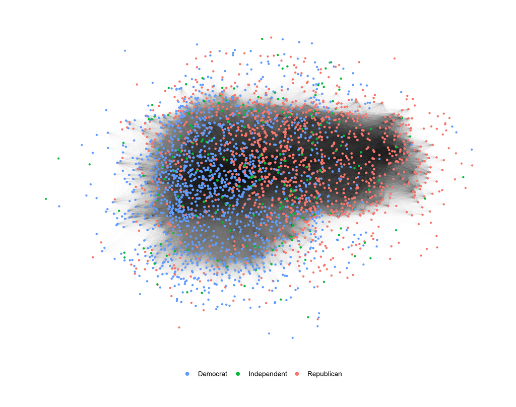

## Inference

Level of expected segregation depends on group size

- In scenario with random choosing, larger groups more segregated
- Using bootstrapping to create null distribution
  - Randomly assign sources to each R
  - Hold # sources constant for each R
  - Weight probability of selecting source by population distribution
- Compare observed SSI to null

## Inference

Spectral segregation index measures for the respondent projection

|  | SSI | Null SSI | SSI - null | Reps. \(\leq\) null |
| --- | --- | --- | --- | --- |
| Democrats | 0.63 | 0.50 | 0.13 | 0.00 |
| Republicans | 0.66 | 0.43 | 0.23 | 0.00 |
| Independents | 0.07 | 0.07 | 0.01 | 0.06 |
| Network | 0.61 | 0.44 | 0.17 | 0.00 |

## Distribution of SSI by party

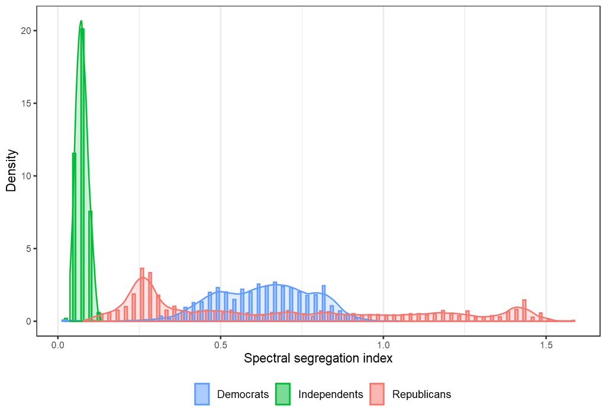

## Takeaways

- SSI shows interesting within- and between-party variation in segregation
- Can be used as individual-level variable for theory testing
- Data requirements:
  - List of sources used by respondents (more is better)
  - Party ID
- Inference procedure probably not needed
  - Null SSI \(\approx\) group’s population proportion
- Can be directly compared to:
  - interpersonal (social) network segregation
  - other countries, media systems, etc.

## Open materials

Paper, slides, code, and data available at:

jacob-long.com